# Minería de Datos: Introducción a las ANNs

Master en Análisis de datos masivos, Big Data (UMU)

Aurora González Vidal, `aurora.gonzalez2@um.es`

17/03/2025

# 1 Introducción

Las redes neuronales artificiales son un modelo computacional inspirado en la estructura y funcionamiento del cerebro humano. Se utilizan ampliamente en problemas de clasificación, regresión y otras tareas de aprendizaje automático.

Esta primera sección, sin adentrarnos en los detalles de tecnología, vamos a ver los principios básicos del deep learning, comenzando por los multi-layer perceptrón, el algoritmo de aprendizaje del backpropagation, y los fundamentos básicos de los frameworks para deep learning como son tensorflow y Pytorch.

# 2 Breve recordatorio de redes neuronales

Recordemos de la asignatura de Aprendizaje Estadístico del primer cuatrimestre que, cuando estudiábamos las redes neuronales, toda red tenía una arquitectura.

Definimos la arquitectura de una red neuronal como el tipo de nodos que encontramos, cómo se disponen en la red, cómo se interconectan y cómo se tratan las salidas de cada nodo

La arquitectura que nos interesa es de tipo fully-connected feed-forward, en la que todos los nodos de la capa $i$ se conectan con todos los de la capa $i+1$.

## 2.1 Perceptrón

El perceptrón es una de las arquitecturas más simples dentro de las redes neuronales. Propuesto por Frank Rosenblatt en 1958, consiste en una capa de nodos de entrada conectados a una única neurona de salida mediante pesos sinápticos ajustables.

En términos generales, una red neuronal puede representarse como un grafo en el que los nodos reciben conexiones de entrada (arcos) y envían conexiones de salida hacia otros nodos o hacia la capa de salida. Los nodos procesan los datos que reciben a través de los arcos, y cada arco está ponderado con un peso que regula la influencia de la señal transmitida.

Las conexiones que llegan a un nodo conforman su fan-in, mientras que las conexiones que salen de él constituyen su fan-out. En el caso más simple, el grafo se reduce a un único nodo, cuyo fan-in está compuesto por los arcos que conectan los predictores del conjunto de entrenamiento con el nodo. A su vez, el fan-out está formado por los arcos que dirigen la información hacia cada componente del vector de salida.

Un ejemplo de esta estructura se puede observar aquí

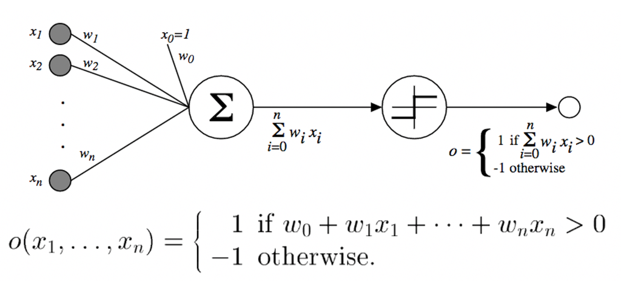

Ejemplo de perceptrón

- Nótese que la salida final del nodo no es el producto punto (*dot product*) de las entradas $x_i$ y los pesos $w_i$, sino una función escalón aplicada a dicho producto. Por tanto, si la cantidad:

$$w_0 + w_1 x_1 + w_2 x_2 + \dots + w_n x_n$$

es positiva, el nodo indicará que el ejemplo presentado a la entrada se clasifica como de la clase positiva. Si, por el contrario, el producto es negativo, la clase asignada será la negativa.

- Dicha forma de transformar un valor real a un valor en $\{-1,1\}$ se denomina **función escalón**.
- El perceptrón así definido se puede usar de manera básica para problemas de clasificación binarios.

### 2.1.1 Algoritmo del Perceptrón

1. Inicializar los pesos aleatoriamente.
2. Para cada ejemplo de entrenamiento:
   - Calcular la salida de la neurona.
   - Comparar con la salida esperada y actualizar los pesos.
3. Repetir hasta que el error sea aceptable o se alcance un número máximo de iteraciones.

### 2.1.2 Regla del gradiente descendente

Cuando el problema no es separable linealmente, la regla del perceptrón puede no converger.

Como solución a ese problema tenemos la regla delta. Se basa en la aplicación de gradiente descendente. Trataremos de minimizar este error:

$$E(\bar{w}) = \frac{1}{2} \sum_{d \in D}
(t_d - o_d)^2,$$

donde $D$ es el conjunto de datos, $\bar{w}$ el conjunto de pesos de los arcos que van al perceptrón, $t_d$ la salida y $o_d$ lo que predice el nodo.

En este punto es importante destacar que si queremos minimizar el error, lo único que está en nuestra mano modificar para ello se reduce a los valores que pueden tomar los pesos en el vector $\bar{w}$. Es por eso que, si el perceptrón es nuestro modelo, los parámetros de dicho modelo son, precisamente, $\bar{w}$.

El mecanismo básico de optimización del error se denomina gradiente descendente. Consiste en aplicar el operador gradiente a la función de error (lo denotamos con $\nabla f(x)$ cuando se aplica a cualquier función $f()$). La dirección de mayor variación del error nos la va a dar la expresión resultante de la derivada parcial del error con respecto a los pesos (i.e. el gradiente de E). Aplicando el operador de gradiente descendente a esa función de error, tenemos que:

$$\nabla E(\bar{w}) = \left[
\frac{\partial E}{\partial w_0}, \frac{\partial E}{\partial w_1}, \dots,
\frac{\partial E}{\partial w_n} \right],$$

¿Cómo usamos entonces ese vector gradiente? Si queremos optimizar los pesos, habrá que hacerlo aplicándoles incrementos, tal que así:

$$\bar{w} \leftarrow \bar{w} +
\Delta\bar{w},$$

donde $\Delta\bar{w}$ representa una cantidad de ajuste que aplicamos a $\bar{w}$ para cambiar su valor ligeramente. Esos incrementos vendrán dados por:

$$\Delta\bar{w} = - \eta \nabla
E(\bar{w}),$$

donde $\eta$ es un número menor que 1 (e.g., $10^{-3}$), denominado ratio de aprendizaje.

El signo negativo se aplica porque el gradiente nos marca la dirección de aumento del error. Como queremos disminuirlo, simplemente cambiamos el sentido al vector cambiándole el signo.

Si lo expresamos particularizado para cada peso:

$$w_i \leftarrow w_i + \Delta
w_i,$$

donde:

$$\Delta w_i = -\eta \frac{\partial
E}{\partial w_i}.$$

Algoritmo cuando la función de activación es la función escalón:

1. **Definición de variables:**
   - Sea cada ejemplo de entrenamiento un par $(\bar{x}, t)$, donde $\bar{x}$ es el vector de valores de input en $\mathbb{R}^n$.
   - Sea $t$ el valor a predecir.
   - Sea $\eta$ un valor menor que 1, e.g. $0.5 \times 10^{-3}$.
   - Sean $w_1, \dots, w_n$ los pesos del perceptrón, uno para cada componente de $\bar{x}$.
2. **Inicializar los pesos** $w_i$ a un valor aleatorio entre $[-0.5,0.5]$.
3. **Repetir mientras no se satisfaga la condición de terminación:**
   - Inicializar $\Delta w_i$ a 0.
   - Para cada $(\bar{x}, t)$:
     - Aplicar $\bar{x}$ al perceptrón, calcular la salida $o$.
     - Para cada peso $w_i$:
       $$\Delta w_i \leftarrow \Delta w_i + \eta (t - o)
       x_i.$$
     - Para cada peso $w_i$:
       $$w_i \leftarrow w_i + \Delta w_i.$$

¿Por qué $\Delta w_i \leftarrow \Delta w_i + \eta (t - o) x_i$ para el perceptrón ?

$$E = \frac{1}{2} \sum_{d \in D} (t_d - o_d)^2$$
$$\frac{\partial E}{\partial w_i} = \sum_{d \in D} (t_d - o_d)
\frac{\partial}{\partial w_i}(t_d - o_d)$$

La actualización de los pesos sigue el gradiente descendente, pero en el caso del perceptrón clásico, no se usa la derivada directamente porque la función escalón no es diferenciable en todos los puntos. En ste caso, se usa la regla de actualización directa basada en el error $(t-o)$.

$$\frac{\partial E}{\partial w_i} = \sum_{d \in D} (t_d - o_d)
\frac{\partial}{\partial w_i}(t_d - w*x_d) = \sum_{d \in D} (t_d -
o_d)(-x_{i,d})$$

Por lo tanto:
$$w_i \leftarrow w_i +
\Delta w_i = w_i - \eta \nabla E(\bar{w}) = w_i -\eta \frac{\partial
E}{\partial w_0} = w_i +\eta \sum_{d \in D} (t_d - o_d)x_{i,d}$$
y por lo tanto:
$$\Delta w_i \leftarrow
\Delta w_i + \eta (t - o) x_i.$$

Ejercicio: Si la función de activación es la sigmoide, ¿cómo se modifica esta fórmula?

# 3 Multilayer Perceptron (MLP)

El perceptrón multicapa (MLP) extiende el modelo del perceptrón simple agregando una o más capas ocultas entre la entrada y la salida. Esto permite que el modelo aprenda relaciones más complejas.

- Un MLP tiene al menos una capa intermedia entre la de los nodos de entrada y los de salida. Esto significa que pasamos de un perceptrón a una red de perceptrones dispuestos en al menos tres niveles diferentes (inputs, capa intermedia y outputs), los cuales normalmente visualizaremos o representaremos de izquierda a derecha.
- Los nodos de la capa de entrada estarán conectados con todos los de la capa intermedia, y los de la intermedia con todos los de la salida (*fully connected*).
- La información fluirá de las entradas a las salidas (*feed forward*).

Como en la figura siguiente, en la que tenemos un MLP para dos variables $X_1$ y $X_2$ a la entrada, una capa oculta de 8 nodos y dos nodos a la salida, para un problema de clasificación binario:

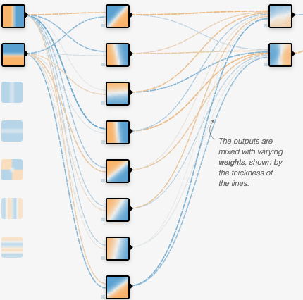

Ejemplo de MLP 1

O el siguiente, de aquí de dos capas ocultas de 8 y 6 nodos respectivamente, para un problema de clasificación de cuatro clases:

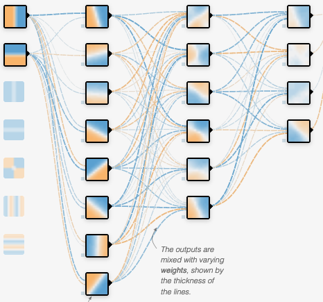

Ejemplo de MLP 2

## 3.1 Backpropagation

Si en un perceptrón, los parámetros a entrenar eran los pesos $w_0, w_1, w_2, \dots, w_n$, y sobre ellos se definía el error, en el caso del MLP los parámetros son los pesos de los arcos del *fan-in* de todos los nodos básicos juntos, $\{ w_{ij} \}$.

Ahora, bajo esta premisa, la función de error se extiende fácilmente considerando que habrá uno o más nodos a la salida:

$$E(\mathbf{w}) = \frac{1}{2} \sum_{d \in D} \sum_{k \in \text{Outputs}}
(t_{kd} - o_{kd})^2$$

donde:

- $k$ hace referencia al nodo de salida correspondiente.
- $d$ itera sobre los ejemplos del conjunto de entrenamiento $D$.
- $\mathbf{w}$ se refiere al *fan-in* de todo nodo $w_{i,j}$ para el nodo $j$-ésimo de la capa $i$-ésima.

Este sería el algoritmo para un MLP de una capa de nodos de entrada, una oculta y una de salida con la sigmoide como función de activación:

*Paso 1: Definición de elementos*

- Sea cada ejemplo de entrenamiento un par $(\mathbf{x}, t)$.
- Sea $\mathbf{x}$ el vector de valores de entrada.
- Sea $t$ el valor a predecir.
- Sea $\eta$ un valor menor que 1, e.g. $0.5 \times 10^{-3}$.
- Sea $\text{out}$ el número de nodos a la salida.
- Sean $o_i, 1 \leq k \leq \text{out}$ las salidas individuales de cada nodo de la capa de salida.

*Paso 2: Inicializar los pesos $w_{i}$*

Asignar valores aleatorios entre $[-0.5, 0.5]$.

*Paso 3: Repetir hasta cumplir la condición de terminación*

Para cada $(\mathbf{x}, t)$ hacer:

1. Aplicar $\mathbf{x}$ a la red y calcular las salidas $o_i, 1 \leq k \leq \text{out}$.
2. Para cada nodo de salida $o_k$ calcular:
   $$\delta_k \leftarrow o_k(1 - o_k)(t_k - o_k)$$
3. Para cada nodo oculto $h$, hacer:
   $$\delta_h \leftarrow o_h(1 - o_h) \sum_{k \in \text{Output}} w_{h,k}
   \delta_k$$
4. Para cada peso $w_{i,j}$, hacer:
   $$w_{i,j} \leftarrow w_{i,j} + \Delta w_{i,j}$$
   donde:
   $$\Delta w_{i,j} = \eta \delta_j x_{i,j}$$

Nótese que los detalles sobre el algoritmo de backpropagation se vieron ya en la asignatura de Aprendizaje Estadístico. Para profundizar más en el tema, se recomienda el siguiente artículo: https://arxiv.org/abs/1609.04747 bien resumida por su autor en la página https://www.ruder.io/optimizing-gradient-descent/. En todo caso, este algoritmo es probablemente uno de los más estudiados en los últimos 15 años, por lo que hay una abundante cantidad de material disponible sobre el mismo.

### 3.1.1 Versiones de entrenamiento

- **Versión batch**: Los pesos se actualizan una vez se ha hecho una pasada completa por el conjunto de entrenamiento.
- **Versión estocástica (on-line)**: Los pesos se actualizan tras cada ejemplo de entrenamiento.
- **Versión minibatch**: Los pesos se actualizan cada cierto número de ejemplos, correspondiente a una proporción del conjunto de entrenamiento (e.g., cada 10%).

La versión *on-line* es computacionalmente más costosa, pero la convergencia suele ser más rápida.

## 3.2 Underfitting y Overfitting

Antes de tratar estos conceptos, debemos recordar qué son el error de entrenamiento y el error de validación. Estos conceptos aplican a redes neuronales, pero también a cualquier modelo de *machine learning*.

- **Error de entrenamiento**: Es el error que comete la red neuronal en ejemplos usados para su entrenamiento. Tiende a ser optimista respecto al error real.
- **Error de validación (o generalización)**: Es el error que comete la red en ejemplos no vistos durante el entrenamiento.

### 3.2.1 Definición de underfitting y overfitting

- **Overfitting**: Cuando el error de entrenamiento es considerablemente mejor que el error de validación. El modelo memoriza los datos en lugar de generalizar.
  - Ejemplo: Un clasificador binario con 95% de precisión en entrenamiento pero solo 70% en validación.
- **Underfitting**: Cuando el error de entrenamiento es alto, indicando que el modelo no ha aprendido patrones útiles.

A continuación, se presenta una gráfica ilustrativa de la relación entre estos errores, la complejidad del modelo y las situaciones de *overfitting* e *underfitting*.

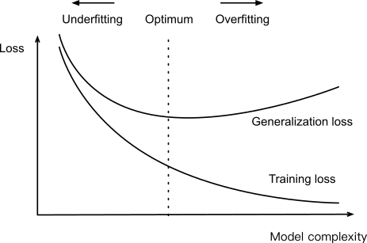

del libro [Dive into deep learning](https://d2l.ai/index.html)

### 3.2.2 Estrategias para el overfitting

- La regularización L2 (weight decay) penaliza los pesos grandes en la función de pérdida para evitar que el modelo se ajuste demasiado a los datos de entrenamiento. Se define como:

$$L = L_0 + \lambda \sum w^2$$

donde $L_0$ es la función de pérdida original y $\lambda$ es el coeficiente de regularización.

El ajuste de pesos en cada iteración del entrenamiento con weight decay se expresa como:

$$\Delta w_i = -\eta \frac{\partial E}{\partial w_i} - \lambda w_i$$

donde $\eta$ es la tasa de aprendizaje y $\lambda$ controla la magnitud de la penalización sobre los pesos.

- El *early stopping* detiene el entrenamiento cuando la pérdida en el conjunto de validación deja de mejorar después de un cierto número de épocas, evitando así el sobreajuste.

# 4 Automatizando la aplicación del gradiente a las funciones de error

En el deep learning, el proceso de obtención de un modelo funcional consiste, normalmente, en:

- Partir de un modelo de red neuronal creado previamente e inicializado de manera aleatoria.
- Usar el dataset de entrenamiento para entrenar los parámetros de la red.
- Hacer el paso anterior repetidamente, de tal forma que el modelo mejore a medida que se le va presentando más datos para su entrenamiento.

Esa mejora del modelo que acabamos de mencionar se traduce en la optimización de una función de error, la *loss function*.

Dicha función de error/pérdida toma como argumento el modelo en su forma actual y estima su nivel de error si lo usáramos para predecir ejemplos nuevos, sin etiquetar (es decir, si lo usáramos en modo producción).

Esto se traduce en la descomposición del proceso de creación del modelo en dos tareas:

- **Optimización**: el proceso que ajusta el modelo a los datos de entrenamiento (esos tres pasos que hemos visto arriba).
- **Generalización**: la forma de comprobar que nuestro modelo va más allá del ajuste a los datos de entrenamiento, midiendo su capacidad de trabajo con nuevos datos, no usados en el *training*.

Para poder llegar a entender al menos de manera básica cómo se trabaja en la actualidad con los modelos de red neuronal, es necesario que entendamos la optimización por gradiente, que se basa en la obtención de derivadas de funciones de error de forma automática.

El resto de este tema lo dedicamos a introducir la [programación diferenciable](https://en.wikipedia.org/wiki/Differentiable_programming) .

## 4.1 El proceso de optimización

[output not shown]

Supongamos que hemos definido una función de error para un algoritmo que busca los mejores pesos $w_i$ en una red neuronal que estamos diseñando.

- Si esta función de error está bien definida, dependerá principalmente de los parámetros del modelo, es decir, $w_i$.

-Consideremos, por ejemplo, un perceptrón que recibe $n$ variables de entrada en el espacio de los números reales y produce una salida real

En este caso, la función de error dependerá de los pesos $w_i, 1\leq i\leq n$ que conectan cada una de las $n$ variables con dicho perceptrón. Matemáticamente, podemos expresarla como:

$$f(w_1, w_2, \dots, w_n)$$

Si queremos optimizar dicha función, tendremos que hacerlo con respecto a todos y cada uno de esos pesos.

### 4.1.1 Derivada de $f()$

La definición de derivada de una función $f(x)$ de una sola variable es:

$$f'(x) = \lim_{h\to0}
\frac{f(x+h)-f(x)}{h}$$

siempre que dicho límite exista. Si así es, decimos que $f$ es derivable.

Como bien sabemos, la derivada modela la velocidad de cambio de la función $f()$, cuando la variable de entrada cambia casi imperceptiblemente.

Cuando estamos en el caso de varias variables, debemos extender la definición a funciones multivariables:

$$f(x_1, x_2, \dots, x_n)$$

y en este caso hablaremos de derivadas parciales ya que en cada caso estaremos derivando con respecto a una de las variables concretas de las que depende la función. Para el caso de la variable $x_i$, tenemos:

$$\frac{\partial y}{\partial x_i} =
\lim\limits_{h\rightarrow 0}
\frac{f(x_1,\ldots,x_{i-1},x_i+h,x_{i+1},\ldots,x_n) -
f(x_1,x_2,\ldots,x_n)}{h}$$

Es decir, para calcular $\frac{\partial y}{\partial x_i}$, tratamos el resto de variables distintas de $x_i$ como constantes y variamos $x_i$ ligeramente.

### 4.1.2 El operador de gradiente y la regla de la cadena

Si quisiéramos encapsular toda esta complejidad en un solo operador que, de una vez, obtenga las derivadas parciales de $f$ con respecto a todas las variables, lo que necesitamos es un gradiente.

Si nuestra función $f$ toma entradas en:

$$X = [x_1, x_2, \dots, x_n]^T$$

y su salida es un real, el gradiente de $f(X)$ con respecto a $X$ es un vector de $n$ derivadas parciales tal que:

$$\nabla_X f(X) = \left[ \frac{\partial
f(X)}{\partial x_1}, \frac{\partial f(X)}{\partial x_2}, \dots,
\frac{\partial f(X)}{\partial x_n} \right]^T$$

Una de las claves del deep learning es que la obtención de los gradientes se automatiza, liberando al programador de trabajar la matemática detrás de la obtención de las derivadas parciales de $f()$.

Dicha automatización se basa en la **regla de la cadena**, que nos permite trabajar con las derivadas de funciones de error compuestas (i.e., formadas por otras funciones más básicas). Si tenemos las funciones:

$$y = f(u)$$

$$u = g(x)$$

(nótese que $y = f(g(x))$), entonces tenemos:

$$\frac{dy}{dx} = \frac{dy}{du} \cdot \frac{du}{dx}$$

Es decir, la derivada de una función compuesta se puede descomponer en el producto de la derivada de dicha función con respecto a la función interna y la derivada de dicha función interna con respecto a la variable de la que ambas dependen.

En el caso en el que las funciones sean multivariables, es decir, si la función $y$ depende de variables $u_1, u_2, \dots, u_m$ y cada una de las $u_i$ es una función derivable que depende de las variables $x_1, x_2, \dots, x_n$, entonces la regla de la cadena se generaliza a:

$$\frac{dy}{dx_i} = \sum_{j=1}^{m} \frac{dy}{du_j} \cdot
\frac{du_j}{dx_i}, \quad \forall i \in [1, n]$$

## 4.2 Reglas Básicas para Gradientes

A este mecanismo básico de diferenciación de funciones compuestas le unimos las siguientes reglas básicas para operaciones con gradientes:

- Para cualquier $A \in \mathbb{R}^{m \times n}$,
  $$\nabla_X (AX) = A^T$$
  o sea el gradiente con respecto a $X$ del producto de una matriz $A$ y dicho vector $X$ donde $A$ tiene $m$ filas y tantas columnas como variables tiene $X$ es la traspuesta de $A$.
- Para cualquier $A \in \mathbb{R}^{n \times m}$,
  $$\nabla_X (X^T A) = A^T$$
  o sea el gradiente con respecto a $X$ del producto de $X^T$ y una matriz $A$, siendo $A$ de tamaño $n \times m$, es la traspuesta de $A$
- Para cualquier $A \in \mathbb{R}^{n \times n}$, el gradiente de la expresión cuadrática $X^T A X$ con respecto a $X$ es:
  $$\nabla_X (X^T A X) = (A + A^T) X$$
  Esto significa que, al calcular la derivada de la función con respecto a cada componente del vector $X$ , obtenemos una nueva expresión en la que la matriz $A$ contribuye tanto con sus valores originales como con su transpuesta
- El gradiente de la norma cuadrática (caso especial del anterior cuando $A$ = $I$ la matriz identidad ):
  $$\nabla_X ||X||^2 = \nabla_X (X^T X) = 2X$$
  Esto significa que cuando tomamos la derivada de la suma de los cuadrados de los elementos de $X$, cada componente $x_i$ contribuye con un término $2x_i$, lo que refleja la tasa de cambio de la función con respecto a cada coordenada de $X$.

## 4.3 Diferenciación automática

La diferenciación automática se basa en el uso de un grafo de computación que representa los diferentes flujos, con sus correspondiente operaciones, por los que atraviesan los datos de training cuando se introducen en nuestro modelo de deep learning.

Este modelo explícito de computación permite así el cálculo de los gradientes en cada parte del modelo y su propagación hacia atrás, todo de forma automática.

Cada parte del modelo (i.e. un nodo de nuestra red), dependen de ciertos pesos correspondientes a los arcos que llegan a ese nodo. Cada peso, por tanto, contribuye la función de error con una intensidad que depende del peso y de la entrada que llega por ese arco. El gradiente sirve para calcular dicha contribución y modificar el peso con una cantidad proporcional.

### 4.3.1 Ejemplo gráfico

Véase la siguiente figura como ilustración animada de cómo fluye un ejemplo de entrenamiento a través de una capa de nodos que conectan la entrada con un conjunto de nodos ocultos con función de activación *ReLU*, y que van a una capa de salida de clasificación con tantos nodos como clases. La función de pérdida (*loss*) es de entropía cruzada. Como puede verse, los gradientes se calculan a partir del ejemplo de entrada y el error en el que se incurre al clasificarlo. Dichos gradientes se propagan por las diferentes matrices de pesos (de la capa de entrada a la oculta, y de la oculta a la capa de salida).

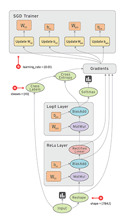

# 5 Grafos computacionales

En un grafo computacional, siguiendo la descripción informal de [Goodfellow et al., 2016](https://www.deeplearningbook.org/),

- Todo nodo es una variable, ya sea esta de tipo escalar, vector, matriz, tensor u otro tipo.
- Las operaciones (representadas por arcos en los grafos) son funciones que se aplican a una o más variables (es decir, uno o más de los nodos del grafo). Dichas operaciones pueden hacerse más complejas haciendo uso de operadores de composición.
- Una operación devolverá únicamente una variable de salida (es decir, otro nodo del grafo).
- Si una variable `y` se calcula mediante la aplicación de una operación a la variable `x`, entonces tanto `x` como `y` son nodos del grafo y existe un arco dirigido desde `x` a `y`.

Usemos como ejemplo la siguiente figura:

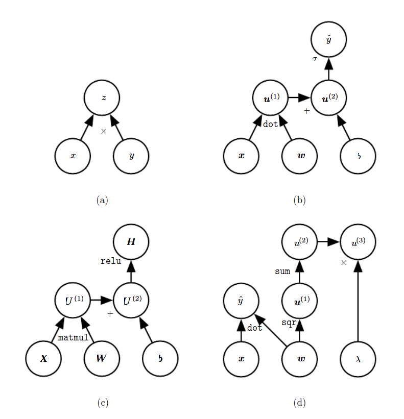

Figura 6.8 de Goodfellow et al. Ejemplos de grafos de computación

En los que en:

1. Tenemos la operación `z = x * y`.
2. Un grafo para la predicción de una regresión logística `y^ = σ(x^T w + b)` (obsérvese que hay nodos en el grafo que no tienen por qué aparecer en la expresión, pero se necesitan para almacenar resultados intermedios, como los `u_i`).
3. Corresponde a la expresión `H = max{0, XW + b}`, que se refiere al cálculo de varias RELUs (Rectified Linear Units) `H` dada una matriz de pesos y un batch de muestras `X`.
4. Se corresponde con un ejemplo en el que se calcula un modelo de regresión lineal, y la misma variable `w` se utiliza también para calcular una penalización `λ ∑_i w_i^2`.

# 6 Introducción a la tecnología subyacente

En la actualidad, si alguien está interesado en el análisis de datos mediante la elaboración de modelos de machine learning, las opciones con las que trabajar son muchas.

- Podríamos elegir entre R o Python como lenguajes.
- Además, debemos decidir si vamos a trabajar sólo con redes neuronales (es decir, mediante la programación diferencial) o si nos interesan otros tipos de enfoques más tradicionales (por ejemplo, regresión lineal/logística, árboles/bosques de decisión).
- Naturalmente, el tipo de problema al que nos vamos a enfrentar también condiciona.

Supongamos, como es el caso aquí, que solo estamos interesados en trabajar con redes neuronales para hacer deep learning.

- La opción más natural, si para nosotros el lenguaje no es un condicionante, es usar tecnologías como TensorFlow (Google) o PyTorch (Facebook).
- Si, por otro lado, nos interesa el deep learning pero no a bajo nivel, sino que queremos usar toda su potencia pero desde una API de más alto nivel, tenemos la opción de Keras, ya sea sobre TensorFlow o sobre PyTorch.

Keras es una API de alto nivel que nos permite especificar, virtualmente, todos los elementos que definen un experimento (capas, embeddings, convoluciones, funciones de error, algoritmos de optimización, etc.) y que nos permite seleccionar la tecnología de bajo nivel para trabajar con deep learning.

Pero si lo que queremos es diseñar algoritmos nuevos, hacer incidencia en aspectos relacionados con la eficiencia, distribuir la evaluación de los grafos de computación, etc., deberíamos considerar utilizar motores de deep learning.

# 7 Referencias

Parte del material de las matemáticas básicas se ha obtenido de https://d2l.ai/chapter_preliminaries/autograd.html.

# 8 Apéndice A

## 8.1 R Keras con TensorFlow

En R Keras, el motor básico que estamos viendo es TensorFlow. En TensorFlow, la API para diferenciación automática es `tf$GradientTape`. Todas las operaciones que tienen lugar en un modelo TensorFlow se graban en el contexto de la variable `tf$GradientTape`, es decir, en una cinta. Esa cinta se usa, junto con los gradientes asociados a cada operación registrada, para calcular los gradientes de los cálculos almacenados usando diferenciación.

El siguiente ejemplo crea una matriz de 2x2 inicializada a 1:

```r
library(tensorflow)

# Creamos una matriz de 2x2, inicializada a unos
x <- tf$ones(shape(2, 2))
x
```

```
## tf.Tensor(
## [[1. 1.]
##  [1. 1.]], shape=(2, 2), dtype=float32)
```

Suma todos los elementos de la matriz, esto da como resultado el escalar 4, y el resultado lo eleva al cuadrado:

```r
with(tf$GradientTape() %as% t, {
  t$watch(x)
  y <- tf$reduce_sum(x)
  cat("Valor de y\n")
  print(y)
  z <- tf$multiply(y, y)
  cat("Valor de z\n")
  print(z)
})
```

```
## Valor de y
## tf.Tensor(4.0, shape=(), dtype=float32)
## Valor de z
## tf.Tensor(16.0, shape=(), dtype=float32)
```

```r
# Derivative of z with respect to the original input tensor x
dz_dx <- t$gradient(z, x)
dz_dx
```

```
## tf.Tensor(
## [[8. 8.]
##  [8. 8.]], shape=(2, 2), dtype=float32)
```

Simbólicamente, lo que hemos hecho ha sido definir la función:

$$f(X) = \left( \sum_{i=1}^{4} x_i \right)^2$$

donde $X = \{x_1, x_2, x_3, x_4\}$. Esta función representa el cuadrado de la suma de los elementos del vector $X$.

El gradiente de $f(X)$ con respecto a $X$ se calcula aplicando la regla de la cadena:

$$\nabla_X f(X) = \left[ \frac{\partial f}{\partial x_1}, \frac{\partial
f}{\partial x_2}, \frac{\partial f}{\partial x_3}, \frac{\partial
f}{\partial x_4} \right].$$

Sabemos que la derivada de $f(X)$ respecto a $X$ es:

$$\frac{\partial f}{\partial x_i} = 2 \sum_{j=1}^{4} x_j.$$

Dado que en nuestro caso cada $x_i = 1$, la suma de todos los elementos es 4:

$$\frac{\partial f}{\partial x_i} = 2 \times 4 = 8, \quad \text{para cada
} i.$$

Por lo tanto, el gradiente de $f(X)$ es:

$$\nabla_X f(X) = [8, 8, 8, 8].$$

En términos matriciales, al tratarse de una matriz $2 \times 2$, el resultado final es:

$$\begin{bmatrix} 8 & 8 \\ 8 & 8 \end{bmatrix}.$$

Ahora, consideremos otro ejemplo. Vamos a diferenciar la función:

$$y = 2X^T X,$$

donde $X$ es un vector. Esta función representa el doble del producto escalar de $X$ consigo mismo.

```r
x <- tf$range(4,dtype = "float32")

with(tf$GradientTape() %as% t, {
  t$watch(x)
  y <- 2 * tf$tensordot(x,x,axes = 1L)
})

# Derivative of z with respect to the original input tensor x
dy_dx <- t$gradient(y,x)
dy_dx
```

```
## tf.Tensor([ 0.  4.  8. 12.], shape=(4), dtype=float32)
```

El gradiente de $y$ con respecto a $X$ se calcula como:

$$\frac{\partial y}{\partial X} = 4X.$$

Esto se debe a que:

$$\frac{\partial}{\partial X} (X^T X) = 2X,$$

y multiplicando por el factor $2$, obtenemos:

$$\frac{\partial y}{\partial X} = 4X.$$

```r
x <- tf$range(4,dtype = "float32")

with(tf$GradientTape() %as% t, {
  t$watch(x)
  y <- 2 * tf$tensordot(x,x,axes = 1L)
})

# Derivative of z with respect to the original input tensor x
dy_dx <- t$gradient(y,x)
dy_dx
```

```
## tf.Tensor([ 0.  4.  8. 12.], shape=(4), dtype=float32)
```

Como sabemos, la derivada de $2x^2$ con respecto a $x$ es $4x$. Matemáticamente, esto se expresa como:

$$\frac{d}{dx} (2x^2) = 4x.$$

Por lo tanto, la derivada $\frac{dx}{dx}$ de la función $2x^2$ debería ser igual a $4x$.

```r
dy_dx == 4 * x
```

```
## tf.Tensor([ True  True  True  True], shape=(4), dtype=bool)
```